# Time-varying Markov models (non-homogeneous)

2016-09-16

In more complex Markov models in health economic evaluation, transition probabilities between states can vary with time. These models are called *non-homogeneous* or *time-inhomogeneous* Markov models. A further distinction can be made depending on whether:

1. transition probabilities depend on how long **the entire model** has been running (model-time variation): this situation can be modelled with a non-homogeneous Markov model;
2. transition probabilities depend on how long **an individual** has been in a state (individual-time variation): this situation usually needs to be modelled with a microsimulation.

However in some special cases non-homogeneous Markov models can be used in situation 2, when the state with transition probabilities depending on individual-time is the starting state **and** it is not possible to go back to that state after having left it. In this situation individual-time is equivalent to model-time. This is the case in the following example.

If you are not familiar with `heemod`, first consult the introduction vignette `vignette("introduction", package = "heemod")`.

# Model description

This example is an implementation of the assessment of a new total hip replacement (THR) technology described in chapter 3.5 of [Decision Modelling for Health Economic Evaluation](http://ukcatalogue.oup.com/product/9780198526629.do). A more detailed report is available [at this location](https://www.york.ac.uk/media/che/documents/papers/technicalpapers/CHE%20Technical%20Paper%2028.pdf), event though this reports goes a bit further in the analysis. For the sake of simplicity we will not reproduce exactly the analysis from the book. See vignette `vignette("reproduction", package = "heemod")` for an exact reproduction of the analysis.

This model has 5 states:

- Primary THR: starting state, individuals receive either the standard or the new THR (called NP1), outcomes are either success of primary THR or death (the operative mortality rate of primary THR will be called `omrPTHR`);
- Success of primary THR: state after receiving primary THR if the surgery is successfull, individuals can stay in that state, need a THR revision, or die of other causes;
- Revision of primary THR: for individuals whose primary THR needed revision, outcomes are either success of revision THR or death (the operative mortality rate of revision THR will be called `omrRTHR`);
- Success of revision THR: state after receiving revision THR if the surgery is successfull, individuals can stay in that state, need a THR re-revision, or die of other causes;
- Death (either caused by THR or another cause).

Two transition probabilities are time-varying in this model:

- Probability of death by another cause increases with age;
- Probability of primary THR revision increases with time.

## Other-Cause death

Other-cause death probabilities (mortality rate `mr`) for the United Kingdom is taken from WHO databases using the `get_who_mr()` function. The variable `sex`, taking values `0` and `1`, must be recoded in `"FMLE"` and `"MLE"` before being passed to this function.

## THR revision

- Primary THR revision probability for the standard THR, called `standardRR` increases with time with the following formula (a [Weibull distribution](https://en.wikipedia.org/wiki/Weibull_distribution)):

$$P_{revision} = 1 - \exp(\lambda \times ((t-1)^\gamma-t^\gamma))$$

Where $t$ is the time since revision, $\gamma = 1.45367786$ and:

$$\lambda = exp(cons + ageC \times age + maleC \times sex)$$

Where `age` and `sex` (female = 0, male = 1) are individual characteristics, `cons` = -5.49094, `ageC` = -0.0367 and `maleC` = 0.768536.

- For the NP1 procedure the standard procedure revision probability `standardRR` is modified by the relative risk `rrNP1` = 0.260677.

$$P_{revision} = 1 - \exp(\lambda \times rrNP1 \times ((t-1)^\gamma-t^\gamma))$$

- Revision THR re-revision (`rrr`) probability is set to be constant at 0.04 per year.

# Parameters definition

In order to build this more complex Markov model, parameters need to be defined through `define_parameters()`. The equations decribed in the previous section can be written easily, here for a female population (`sex` = 0) starting at 60 years old (`age_init` = 60).

Note that state values that are going to be discounted need to be defined through `define_parameters()`.

```r
param <- define_parameters(
    age_init = 60,
    sex = 0,
    # age increases with cycles
    age = age_init + markov_cycle,

    # operative mortality rates
    omrPTHR = .02,
    omrRTHR = .02,

    # re-revision mortality rate
    rrr = .04,

    # parameters for calculating primary revision rate
    cons = -5.49094,
    ageC = -.0367,
    maleC = .768536,
    lambda = exp(cons + ageC * age_init + maleC * sex),
    gamma = 1.45367786,

    rrNP1 = .260677,

    # revision probability of primary procedure
    standardRR = 1 - exp(lambda * ((markov_cycle - 1) ^ gamma -
                                     markov_cycle ^ gamma)),
    np1RR = 1 - exp(lambda * rrNP1 * ((markov_cycle - 1) ^ gamma -
                                        markov_cycle ^ gamma)),

    # age-related mortality rate
    sex_cat = ifelse(sex == 0, "FMLE", "MLE"),
    mr = get_who_mr(age, sex_cat, country = "GBR"),

    # state values
    u_SuccessP = .85,
    u_RevisionTHR = .30,
    u_SuccessR = .75,
    c_RevisionTHR = 5294
)
param
```

```
## 20 unevaluated parameters.
##
## age_init = 60
## sex = 0
## age = age_init + markov_cycle
## omrPTHR = 0.02
## omrRTHR = 0.02
## rrr = 0.04
## cons = -5.49094
## ageC = -0.0367
## maleC = 0.768536
## lambda = exp(cons + ageC * age_init + maleC * sex)
## gamma = 1.45367786
## rrNP1 = 0.260677
## standardRR = 1 - exp(lambda * ((markov_cycle - 1)^gamma - markov_cycle^gamma))
## np1RR = 1 - exp(lambda * rrNP1 * ((markov_cycle - 1)^gamma - markov_cycle^gamma))
## sex_cat = ifelse(sex == 0, "FMLE", "MLE")
## mr = get_who_mr(age, sex_cat, country = "GBR")
## u_SuccessP = 0.85
## u_RevisionTHR = 0.3
## u_SuccessR = 0.75
## c_RevisionTHR = 5294
```

# Transition matrix definition

Now that parameters are defined, the probability transitions can be easily written:

```r
mat_standard <- define_matrix(
    state_names = c(
      "PrimaryTHR",
      "SuccessP",
      "RevisionTHR",
      "SuccessR",
      "Death"
    ),
    0, C, 0,          0, omrPTHR,
    0, C, standardRR, 0, mr,
    0, 0, 0,          C, omrRTHR+mr,
    0, 0, rrr,        C, mr,
    0, 0, 0,          0, 1
)
mat_standard
```

```
## An unevaluated matrix, 5 states.
##
##             PrimaryTHR SuccessP RevisionTHR SuccessR Death
## PrimaryTHR             C                             omrPTHR
## SuccessP               C        standardRR           mr
## RevisionTHR                                 C        omrRTHR + mr
## SuccessR                        rrr         C        mr
## Death                                                1
```

```r
mat_np1 <- define_matrix(
    state_names = c(
      "PrimaryTHR",
      "SuccessP",
      "RevisionTHR",
      "SuccessR",
      "Death"
    ),
    0, C, 0,          0, omrPTHR,
    0, C, np1RR,      0, mr,
    0, 0, 0,          C, omrRTHR+mr,
    0, 0, rrr,        C, mr,
    0, 0, 0,          0, 1
)
mat_np1
```

```
## An unevaluated matrix, 5 states.
##
##             PrimaryTHR SuccessP RevisionTHR SuccessR Death
## PrimaryTHR             C                             omrPTHR
## SuccessP               C        np1RR                mr
## RevisionTHR                                 C        omrRTHR + mr
## SuccessR                        rrr         C        mr
## Death                                                1
```

While it is possible to plot the matrix thanks to the `diagram` package, the results may not always be easy to read.

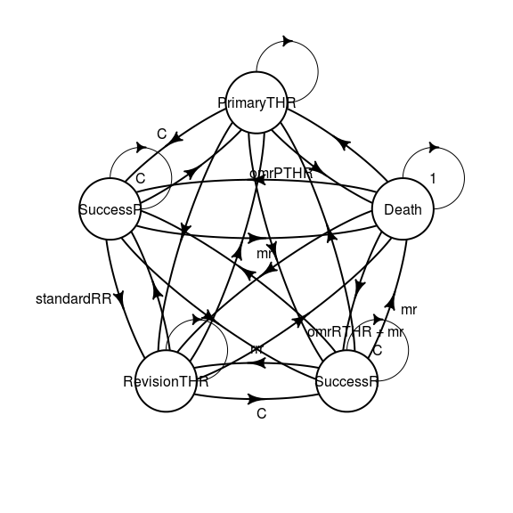

```r
plot(mat_standard)
```

# State & model definition

Utilities and costs are then associated to states. In this model costs are discounted at a rate of 6% and utilities at a rate of 1.5%.

Now that parameters, transition matrix and states are defined we can define the models for the control group and the NP1 treatment.

```r
mod_standard <- define_model(
  transition_matrix = mat_standard,
  PrimaryTHR = define_state(
    utility = 0,
    cost = 394
  ),
  SuccessP = define_state(
    utility = discount(u_SuccessP, .015),
    cost = 0
  ),
  RevisionTHR = define_state(
    utility = discount(u_RevisionTHR, .015),
    cost = discount(c_RevisionTHR, .06)
  ),
  SuccessR = define_state(
    utility = discount(u_SuccessR, .015),
    cost = 0
  ),
  Death = define_state(
    utility = 0,
    cost = 0
  )
)
mod_standard
```

```
## An unevaluated Markov model:
##
##     5 states,
##     2 state values
```

```r
mod_np1 <- define_model(
  transition_matrix = mat_np1,
  PrimaryTHR = define_state(
    utility = 0,
    cost = 579
  ),
  SuccessP = define_state(
    utility = discount(u_SuccessP, .015),
    cost = 0
  ),
  RevisionTHR = define_state(
    utility = discount(u_RevisionTHR, .015),
    cost = discount(c_RevisionTHR, .06)
  ),
  SuccessR = define_state(
    utility = discount(u_SuccessR, .015),
    cost = 0
  ),
  Death = define_state(
    utility = 0,
    cost = 0
  )
)
```

# Model analysis

Both models can now be run for 60 years. By default models are computed for 1000 person starting in `PrimaryTHR`. To replicate results from the original study we assume transitions occur at the end of each cycles. This is necessary because THR cost defined in state `PrimaryTHR` need to be accounted for all 1000 individuals.

```r
res_mod <- run_models(
  standard = mod_standard,
  np1 = mod_np1,
  parameters = param,
  cycles = 60,
  cost = cost,
  effect = utility,
  method = "end"
)
```

```
## Fetching mortality data from WHO server.
```

```
## Using latest year: 2015
```

```r
summary(res_mod)
```

```
## 2 Markov models run for 60 cycles.
##
## Initial states:
##
##                N
## PrimaryTHR  1000
## SuccessP       0
## RevisionTHR    0
## SuccessR       0
## Death          0
##
## Counting method: 'end'.
##
##           utility     cost
## standard 16118.73 525457.1
## np1      16170.51 613783.6
##
## Efficiency frontier:
##
## standard np1
##
## Model difference:
##
##         Cost     Effect     ICER
## np1 88.32658 0.05177584 1705.942
```

It should be noted that this result differs from the original study. This difference is explained by higher population-level all-causes mortality rates in the original study than in the WHO database (used here). See vignette `vignette("reproduction", package = "heemod")` for an exact reproduction of the analysis.

We can plot the counts per state for the *standard* model:

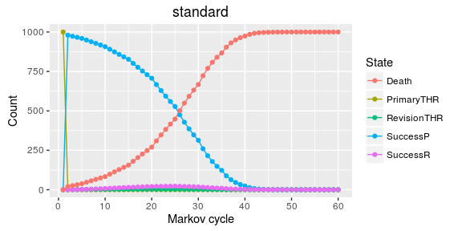

```r
plot(res_mod, model = "standard", type = "counts")
```

And the *np1* model:

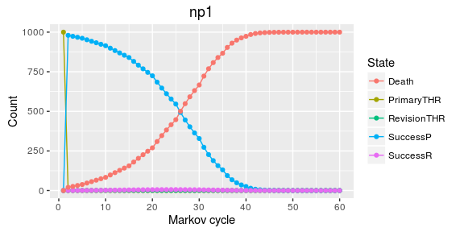

```r
plot(res_mod, model = "np1", type = "counts")
```